# Community changes modelling

Моделирование изменений в сообществах бентоса при двух гидрологических режимах было основано на следующем алгоритме.

1. Была построена модель, описывающая связь структуры сообщества бентоса с гидрологическими характеристиками акватории, находящимися в режиме “Native” (без проведения гидротехнических работ). При этом в качестве матрицы зависимых переменных выступал массив плотностей поселения видов. В качестве предикторов в модель были включены соленость, зональная компонента скорости течения, меридианальная составляющая скорости течения. Для формирования матрицы предикторов для каждой станции, на которой проводилось взятие проб бентоса, были получены предсказанные моделью **INMOM** значения указанных параметров для каждого дня календарного года. Далее значения солености были усреднены. Значения скоростей течений усреднялись без учета знака, характеризующего направление течения (**NB, если я правильно понял этот знак**).

**Замечание.** Включение в модель величин, производных от указанных параметров (например, количество дней в году, когда соленость была выше определенного значения) приводило к появлению коллинеарности предикторов. В связи с этим, мы включили в модель только три указанных параметра, которые не демонстрировали признаков взаимозависимости.

Связь с соленостью описывалась полиномом 2 степени. Связь со скоростями течения, как линейные функции.

Построение модели осуществлялось с помощью пакета “Hmsс” (Tikhonov, Ovaskainen, Oksanen, 2021).

2. С помощью модели **INMOM** были получены значения предикторов для сценария “Constructed”, то есть после проведения гидротехнических работ. На основе этих данных была получена матрица значений предикторов в точках взятия бентосных проб, аналогичная той, которая была использована при построении модели.
3. Используя коэффициенты, подобранные на шаге 1, была сконструирована матрица обилий, характеризующая “предсказанное” сообщество при сценарии “Constructed”.
4. Используя данные по биомассе видов в пробах были вычислены средние веса особей для каждого вида. Далее на основе этих данных были получены суммарные биомассы бентоса предсказанные моделью для двух гидрологических режимов.
5. Для оценки степени различий между суммарными биомассами сообществ в режиме “Native” и режиме “Constructed” была введена величина

$$Dif = ln(\frac{B_{Constructed}}{B_{Native}})$$

Положительные значения этой величины свидетельствуют о возрастании суммарной биомассы после проведения гидротехнических работ, а отрицательные - о их падении.

В целом, значительных изменений в сообществах при двух гидрологических режимах не выявляется. Однако, согласно предсказаниям модели, до дноуглубительных работ средняя суммарная биомасса составляет 33.4988 г/м<sup>2</sup>, а после после их проведения ожидается, что суммарная биомасса сократится и составит 33.1766 г/м<sup>2</sup>. Таким образом, по сравнению с режимом “Native” при режиме “Constructed” ожидается сокращение суммарной биомассы на 0.96%.

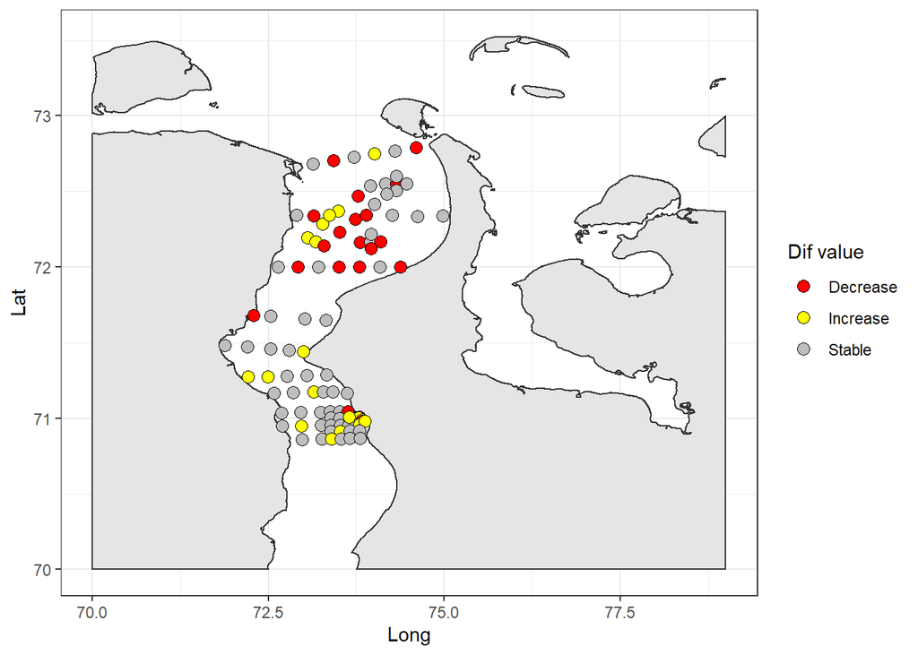

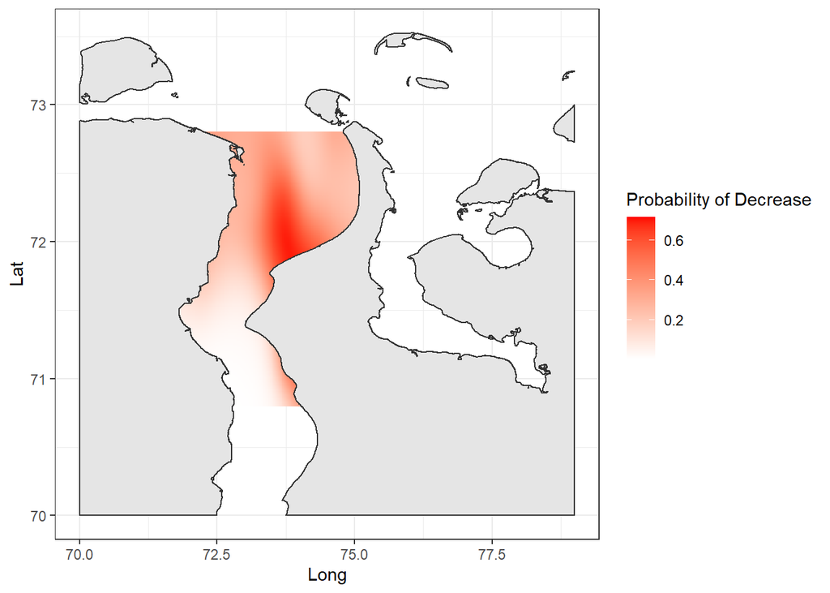

Сопоставление предсказанных моделью обилий отдельных видов позволяет выявить формы, обилие которых, согласно прогнозу, должно сократиться. К числу таких видов относятся следующие: Nemertea gen. sp., Limnodrilus hoffmeisteri , Marenzelleria sp., Ostracoda gen. sp., Copepoda gen. sp., Saduria entomon, Monoporeia affinis, Pontoporeia femorata. Важно отметить, что к числу видов, для которых прогнозируется сокращение обилия, относятся самые массовые для Обской губы виды ракообразных (Saduria entomon, Monoporeia affinis, Pontoporeia femorata), которые составляют основу для питания бентоядных видов рыб. Увеличение обилия ожидается для следующих таксонов:Ampharete vega , Halicryptus spinulosus, Sipunculidea gen. sp., Cumacea gen. sp., Diastylis sulcata, Onisimus sp., Portlandia aestuariorum, Oligochaeta.